# 1. Important Information

The research goal of this notebook is to develop and evaluate machine learning models for predicting weekly rice pest outbreaks using historical field observations and associated environmental conditions. The analysis focuses on constructing a practical decision support component that can help identify high-risk weeks and locations, thereby supporting more timely and targeted pest management interventions. The dataset used in this notebook is the publicly available [ICAR-CRIDA](http://www.icar-crida.res.in:8080/naip/AccessData.jsp) rice pest and disease dataset, which has been aggregated and shared via [Kaggle](https://www.kaggle.com/datasets/zsinghrahulk/rice-pest-and-diseases/data) as a unified CSV file for multiple pests, locations, and years.

This notebook operationalises the data preparation, modelling, and evaluation pipeline described in the research proposal and methodology chapters. It implements the planned steps of exploratory data analysis, feature engineering, target construction (Outbreak), baseline modelling with logistic regression, advanced ensemble models (Random Forest and Gradient Boosting), and a sequence-based Long Short-Term Memory (LSTM) model for a selected pest–location series. Throughout, the notebook aims to remain aligned with the study’s objectives of building transparent, reproducible, and practically interpretable pest outbreak prediction models for rice production systems.

# 2. Loading The Data

Import all of the necessary libraries:

```python
import numpy as np
import pandas as pd
import matplotlib.pyplot as plt
import plotly.express as px
```

Load the data from the '.csv' file into a 'pandas dataframe'.

```python
data = pd.read_csv('RICE.csv')
print(data.info())
data.head()
```

```
<class 'pandas.core.frame.DataFrame'>
RangeIndex: 19404 entries, 0 to 19403
Data columns (total 14 columns):
 #   Column            Non-Null Count  Dtype
---  ------            --------------  -----
 0   Observation Year  19404 non-null  int64
 1   Standard Week     19404 non-null  int64
 2   Pest Value        19404 non-null  float64
 3   Collection Type   19404 non-null  object
 4   MaxT              19404 non-null  float64
 5   MinT              19404 non-null  float64
 6   RH1(%)            19404 non-null  float64
 7   RH2(%)            19404 non-null  float64
 8   RF(mm)            19404 non-null  float64
 9   WS(kmph)          19404 non-null  float64
 10  SSH(hrs)          19404 non-null  float64
 11  EVP(mm)           19404 non-null  float64
 12  PEST NAME         19404 non-null  object
 13  Location          19404 non-null  object
dtypes: float64(9), int64(2), object(3)
memory usage: 2.1+ MB
None
```

|  | Observation Year | Standard Week | Pest Value | Collection Type | MaxT | MinT | RH1(%) | RH2(%) | RF(mm) | WS(kmph) | SSH(hrs) | EVP(mm) | PEST NAME | Location |
| --- | --- | --- | --- | --- | --- | --- | --- | --- | --- | --- | --- | --- | --- | --- |
| 0 | 2003 | 1 | 0.0 | Number/hill | 27.9 | 14.8 | 94.7 | 51.3 | 0.0 | 3.1 | 8.7 | 2.7 | Brownplanthopper | Cuttack |
| 1 | 2003 | 2 | 0.0 | Number/hill | 27.2 | 15.0 | 93.9 | 53.1 | 0.0 | 2.1 | 8.7 | 2.4 | Brownplanthopper | Cuttack |
| 2 | 2003 | 3 | 0.0 | Number/hill | 28.7 | 18.3 | 94.1 | 56.7 | 0.6 | 4.8 | 6.7 | 2.8 | Brownplanthopper | Cuttack |
| 3 | 2003 | 4 | 0.0 | Number/hill | 25.3 | 16.4 | 90.9 | 57.4 | 0.3 | 6.5 | 5.3 | 3.0 | Brownplanthopper | Cuttack |
| 4 | 2003 | 5 | 0.0 | Number/hill | 28.8 | 18.7 | 95.7 | 55.0 | 0.0 | 5.2 | 6.3 | 2.8 | Brownplanthopper | Cuttack |

# 3. Data Exploration

## 3.1 Attribute Analysis

### Understanding Each Feature

- **Observation Year**: The fiscal year that the observation / reading was made.
- **Standard Week**: The week of the year that the observation / reading was made (Ranging from 1 to 52).
- **Pest Value**: The numerical value of the reading that was taken. This is used to create the target attribute.
- **Collection Type**: The process / procedure used to take the reading.
- **MaxT**: The maximum temperature during the respective week.
- **MinT**: The minimum temperature during the respective week.
- **RH1(%)**: The maximum relative humidity during the respective week.
- **RH2(%)**: The minimum relative humidity during the respective week.
- **RF(mm)**: The rainfall (in mm) during the respective week.
- **WS(kmph)**: The wind speed (in kmph) during the respective week.
- **SSH(hrs)**: The average sunshine hours per day during the respective week.
- **EVP(mm)**: The evaporation (in mm) during the respective week.
- **Pest Name**: The recorded pest's name.
- **Location**: The location where the reading was collected / recorded.

### Coverage

```python
data.describe()
```

|  | Observation Year | Standard Week | Pest Value | MaxT | MinT | RH1(%) | RH2(%) | RF(mm) | WS(kmph) | SSH(hrs) | EVP(mm) |
| --- | --- | --- | --- | --- | --- | --- | --- | --- | --- | --- | --- |
| count | 19404.000000 | 19404.000000 | 19404.000000 | 19404.000000 | 19404.000000 | 19404.000000 | 19404.000000 | 19404.000000 | 19404.000000 | 19404.000000 | 19404.000000 |
| mean | 2000.024789 | 26.473717 | 807.944081 | 31.169006 | 20.404540 | 82.190981 | 53.725763 | 19.414152 | 4.501268 | 6.858529 | 5.877180 |
| std | 9.827306 | 15.016247 | 5290.180315 | 4.904610 | 5.388381 | 13.846883 | 18.948801 | 39.160009 | 3.194973 | 4.176542 | 6.536221 |
| min | 1959.000000 | 1.000000 | 0.000000 | 10.900000 | 0.800000 | 9.300000 | 6.700000 | 0.000000 | 0.000000 | 0.000000 | 0.000000 |
| 25% | 1996.000000 | 13.000000 | 0.000000 | 28.800000 | 17.500000 | 79.100000 | 38.000000 | 0.000000 | 2.300000 | 4.900000 | 2.900000 |
| 50% | 2001.000000 | 26.000000 | 3.000000 | 30.900000 | 22.000000 | 87.300000 | 56.600000 | 0.000000 | 3.700000 | 7.300000 | 4.000000 |
| 75% | 2007.000000 | 39.000000 | 92.000000 | 33.425000 | 24.400000 | 91.000000 | 69.000000 | 21.400000 | 5.900000 | 8.900000 | 6.000000 |
| max | 2011.000000 | 52.000000 | 311169.000000 | 71.600000 | 30.900000 | 100.000000 | 95.100000 | 444.400000 | 27.600000 | 127.100000 | 68.300000 |

### "Collection Type"

This shows that there are 5 different 'Collection Types' used to collect the 'Pest Value'. There are no deviations or inconsistencies with the names, therefore no normalization is needed.

```python
print(data['Collection Type'].describe())
print('')
print(data['Collection Type'].unique())
print('')
print(data['Collection Type'].value_counts())
```

```
count                 19404
unique                    5
top       Number/Light trap
freq                  16430
Name: Collection Type, dtype: object

['Number/hill' 'Number/Light trap' 'Percent Damage'
 'Number/Pheromone trap' 'Percentage']

Collection Type
Number/Light trap        16430
Percentage                2298
Number/Pheromone trap      520
Percent Damage             104
Number/hill                 52
Name: count, dtype: int64
```

#### Why This Distribution Matters

Understanding the distribution of “Collection Type” is important because it reveals how pest pressure is quantified across the dataset. Different collection methods (e.g. number per hill, light trap counts, percentage damage) represent different measurement scales and sampling intensities, which can influence the magnitude and variability of recorded values. A dominant method, such as “Number/Light trap”, indicates that most observations follow a similar protocol, reducing heterogeneity in the target definition but also implying that models may implicitly learn patterns that are tied to this specific sampling design rather than being fully method-agnostic.

From a modelling perspective, imbalances in collection types can introduce bias if the model associates particular methods with higher or lower outbreak probability, independent of true biological risk. Treating “Collection Type” as an explicit categorical feature helps the model adjust for these systematic differences and supports fairer comparison across pests and locations using different monitoring protocols.

### "Pest Name"

```python
print(data['PEST NAME'].describe())
print('')
print(data['PEST NAME'].unique())
print('')
print(data['PEST NAME'].value_counts())
```

```
count               19404
unique                 11
top       Yellowstemborer
freq                 4333
Name: PEST NAME, dtype: object

['Brownplanthopper' 'Gallmidge' 'Greenleafhopper' 'LeafFolder'
 'Yellowstemborer' 'Caseworm' 'Miridbug' 'Whitebackedplanthopper'
 'ZigZagleafhopper' 'LeafBlast' 'NeckBlast']

PEST NAME
Yellowstemborer           4333
Gallmidge                 3016
Greenleafhopper           2287
LeafBlast                 2090
Brownplanthopper          1958
LeafFolder                1716
Whitebackedplanthopper    1248
Miridbug                  1144
Caseworm                   936
ZigZagleafhopper           468
NeckBlast                  208
Name: count, dtype: int64
```

#### Why this distribution matters

The distribution of “PEST NAME” shows that some pests, such as Yellowstemborer and Gallmidge, are much more frequently observed than others. This imbalance directly affects how much information the models can learn about each pest’s outbreak dynamics. Pests with many observations provide richer signals for understanding the relationship between weather, time, and pest pressure, whereas pests with relatively few records contribute less to model training and may be predicted with lower reliability.

These frequency differences also have implications for evaluation and generalisation. If model performance is dominated by high-volume pests, overall metrics can look strong even if predictions are less accurate for rarer pests. Explicitly examining pest-wise counts and including “PEST NAME” as a feature ensures that this heterogeneity is recognised and that interpretations of model behaviour acknowledge which pests are best supported by the data.

### "Location"

```python
print(data['Location'].describe())
print('')
print(data['Location'].unique())
print('')
print(data['Location'].value_counts())
```

```
count        19404
unique           6
top       Maruteru
freq          7053
Name: Location, dtype: object

['Cuttack' 'Ludhiana' 'Maruteru' 'Palampur' 'Raipur' 'Rajendranagar']

Location
Maruteru         7053
Rajendranagar    5539
Raipur           2132
Ludhiana         1976
Cuttack          1456
Palampur         1248
Name: count, dtype: int64
```

#### Why this distribution matters

The “Location” distribution indicates that a small number of sites, particularly Maruteru and Rajendranagar, contribute a large proportion of the records. This concentration implies that the models will primarily learn outbreak patterns that are characteristic of these environments, including their specific climate regimes, agronomic practices, and pest complexes. Locations with fewer records, such as Cuttack and Palampur, will be less influential in model fitting and may exhibit higher uncertainty in predictions.

For generalisation, this imbalance means that global performance metrics can be heavily driven by well-represented locations. It is therefore important to both include “Location” as an input feature and to conduct location-wise evaluation (e.g. leave-one-location-out testing), so that the robustness of the models across different agro-ecological contexts can be critically assessed.

## 3.2 Pest Name Analysis

### "Brownplanthopper"

```python
data_BrownPlanthopper = data[data['PEST NAME'] == 'Brownplanthopper']
print(data_BrownPlanthopper['Collection Type'].value_counts())
print('')
print(data_BrownPlanthopper['Location'].value_counts())
```

```
Collection Type
Number/Light trap    1906
Number/hill            52
Name: count, dtype: int64

Location
Maruteru         918
Rajendranagar    624
Ludhiana         312
Cuttack           52
Raipur            52
Name: count, dtype: int64
```

### "Gallmidge"

```python
data_Gallmidge = data[data['PEST NAME'] == 'Gallmidge']
print(data_Gallmidge['Collection Type'].value_counts())
print('')
print(data_Gallmidge['Location'].value_counts())
```

```
Collection Type
Number/Light trap    2912
Percent Damage        104
Name: count, dtype: int64

Location
Maruteru         884
Cuttack          832
Rajendranagar    728
Raipur           520
Ludhiana          52
Name: count, dtype: int64
```

### "Greenleafhopper"

```python
data_Greenleafhopper = data[data['PEST NAME'] == 'Greenleafhopper']
print(data_Greenleafhopper['Collection Type'].value_counts())
print('')
print(data_Greenleafhopper['Location'].value_counts())
```

```
Collection Type
Number/Light trap    2287
Name: count, dtype: int64

Location
Maruteru         831
Rajendranagar    676
Raipur           416
Ludhiana         312
Cuttack           52
Name: count, dtype: int64
```

### "LeafFolder"

```python
data_LeafFolder = data[data['PEST NAME'] == 'LeafFolder']
print(data_LeafFolder['Collection Type'].value_counts())
print('')
print(data_LeafFolder['Location'].value_counts())
```

```
Collection Type
Number/Light trap    1716
Name: count, dtype: int64

Location
Maruteru         884
Rajendranagar    312
Ludhiana         260
Raipur           208
Cuttack           52
Name: count, dtype: int64
```

### "Yellowstemborer"

```python
data_Yellowstemborer = data[data['PEST NAME'] == 'Yellowstemborer']
print(data_Yellowstemborer['Collection Type'].value_counts())
print('')
print(data_Yellowstemborer['Location'].value_counts())
```

```
Collection Type
Number/Light trap        3813
Number/Pheromone trap     520
Name: count, dtype: int64

Location
Rajendranagar    1629
Maruteru          936
Ludhiana          676
Raipur            624
Cuttack           468
Name: count, dtype: int64
```

### "Caseworm"

```python
data_Caseworm = data[data['PEST NAME'] == 'Caseworm']
print(data_Caseworm['Collection Type'].value_counts())
print('')
print(data_Caseworm['Location'].value_counts())
```

```
Collection Type
Number/Light trap    936
Name: count, dtype: int64

Location
Maruteru         468
Rajendranagar    260
Raipur           156
Ludhiana          52
Name: count, dtype: int64
```

### "Miridbug"

```python
data_Miridbug = data[data['PEST NAME'] == 'Miridbug']
print(data_Miridbug['Collection Type'].value_counts())
print('')
print(data_Miridbug['Location'].value_counts())
```

```
Collection Type
Number/Light trap    1144
Name: count, dtype: int64

Location
Maruteru         780
Rajendranagar    260
Ludhiana          52
Raipur            52
Name: count, dtype: int64
```

### "Whitebackedplanthopper"

```python
data_Whitebackedplanthopper = data[data['PEST NAME'] == 'Whitebackedplanthopper']
print(data_Whitebackedplanthopper['Collection Type'].value_counts())
print('')
print(data_Whitebackedplanthopper['Location'].value_counts())
```

```
Collection Type
Number/Light trap    1248
Name: count, dtype: int64

Location
Maruteru    884
Ludhiana    260
Raipur      104
Name: count, dtype: int64
```

### "ZigZagleafhopper"

```python
data_ZigZagleafhopper = data[data['PEST NAME'] == 'ZigZagleafhopper']
print(data_ZigZagleafhopper['Collection Type'].value_counts())
print('')
print(data_ZigZagleafhopper['Location'].value_counts())
```

```
Collection Type
Number/Light trap    468
Name: count, dtype: int64

Location
Maruteru    468
Name: count, dtype: int64
```

### "LeafBlast"

```python
data_LeafBlast = data[data['PEST NAME'] == 'LeafBlast']
print(data_LeafBlast['Collection Type'].value_counts())
print('')
print(data_LeafBlast['Location'].value_counts())
```

```
Collection Type
Percentage    2090
Name: count, dtype: int64

Location
Palampur         1092
Rajendranagar     998
Name: count, dtype: int64
```

### "NeckBlast"

```python
data_NeckBlast = data[data['PEST NAME'] == 'NeckBlast']
print(data_NeckBlast['Collection Type'].value_counts())
print('')
print(data_NeckBlast['Location'].value_counts())
```

```
Collection Type
Percentage    208
Name: count, dtype: int64

Location
Palampur         156
Rajendranagar     52
Name: count, dtype: int64
```

### Summary of pest-wise monitoring patterns

The pest-wise breakdown reveals that most insect pests in this dataset are monitored predominantly via “Number/Light trap” methods, often at multiple locations, whereas some disease-related entries such as LeafBlast and NeckBlast use percentage-based measures of damage. This distinction is important because trap counts and percentage damage reflect different underlying processes: the former captures adult or mobile insect activity, while the latter reflects cumulative injury to the crop canopy or panicles. As a result, identical “Pest Value” magnitudes are not directly comparable across pests without taking the collection type into account.

The location distributions by pest further show that sites such as Maruteru and Rajendranagar dominate surveillance for key pests, while others are more sparsely represented. This concentration of observations implies that the learned models will be particularly well-calibrated for pests and locations with dense monitoring histories, but may be less certain when extrapolating to pests or regions with limited data. Explicitly encoding both “PEST NAME” and “Location”, and interpreting results with these imbalances in mind, is therefore essential for a fair assessment of model performance and for drawing responsible conclusions about their potential use in decision support.

## 3.3 Data Visualization

### Attribute Frequency

#### Bar Charts

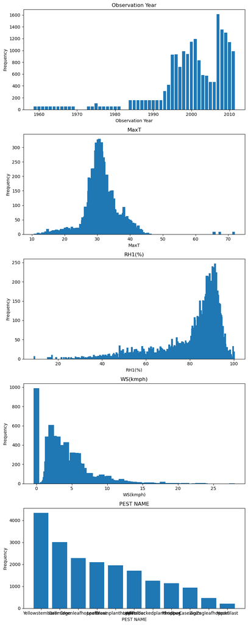

```python
# Select the columns for bar plots
columns = ['Observation Year', 'MaxT', 'RH1(%)', 'WS(kmph)', 'PEST NAME']

# Create subplots for bar plots
fig, axs = plt.subplots(len(columns), 1, figsize=(8, 4*len(columns)))

# Create bar plots for each column
for i, column in enumerate(columns):
    # Count the frequency of each unique value in the column
    value_counts = data[column].value_counts()

    # Plotting the bar graph
    axs[i].bar(value_counts.index, value_counts.values)
    axs[i].set_title(column)
    axs[i].set_xlabel(column)
    axs[i].set_ylabel("Frequency")

# Adjust the spacing between subplots
plt.tight_layout()

# Display the plots
plt.show()
```

#### Pie Charts

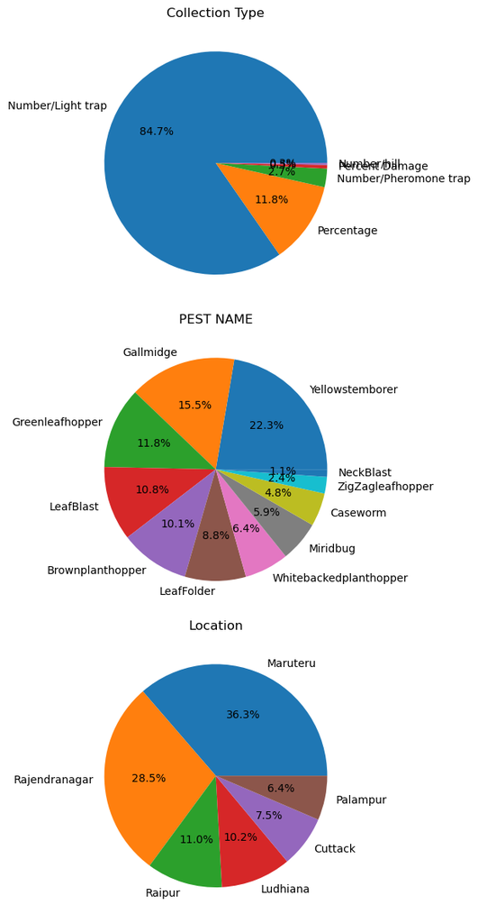

```python
# Select the columns for pie charts
columns = ['Collection Type', 'PEST NAME', 'Location']

# Create subplots for pie charts (stacked vertically)
fig, axs = plt.subplots(len(columns), 1, figsize=(8, 4*len(columns)))

# Ensure axs is iterable for single subplot case
if len(columns) == 1:
    axs = [axs]

# Create pie charts for each column
for i, column in enumerate(columns):
    # Count the frequency of each unique value in the column
    value_counts = data[column].value_counts()

    # Plotting the pie chart
    axs[i].pie(value_counts, labels=value_counts.index, autopct='%1.1f%%')
    axs[i].set_title(column)

# Adjust the spacing between subplots
plt.tight_layout()

# Display the plots
plt.show()
```

# 4. Data Preprocessing

## 4.1 Creating The Target Attribute

The "Outbreak" attribute is used as the target attribute for the Machine Learning Models for the "pest outbreak prediction", which is a typical Decision Support System (DSS). It is created with the following logic:

"If the 'Pest Value' is anything above '0', it is seen as an outbreak."

```python
data['Outbreak'] = (data['Pest Value'] > 0).astype(int)
data.head()
```

|  | Observation Year | Standard Week | Pest Value | Collection Type | MaxT | MinT | RH1(%) | RH2(%) | RF(mm) | WS(kmph) | SSH(hrs) | EVP(mm) | PEST NAME | Location | Outbreak |
| --- | --- | --- | --- | --- | --- | --- | --- | --- | --- | --- | --- | --- | --- | --- | --- |
| 0 | 2003 | 1 | 0.0 | Number/hill | 27.9 | 14.8 | 94.7 | 51.3 | 0.0 | 3.1 | 8.7 | 2.7 | Brownplanthopper | Cuttack | 0 |
| 1 | 2003 | 2 | 0.0 | Number/hill | 27.2 | 15.0 | 93.9 | 53.1 | 0.0 | 2.1 | 8.7 | 2.4 | Brownplanthopper | Cuttack | 0 |
| 2 | 2003 | 3 | 0.0 | Number/hill | 28.7 | 18.3 | 94.1 | 56.7 | 0.6 | 4.8 | 6.7 | 2.8 | Brownplanthopper | Cuttack | 0 |
| 3 | 2003 | 4 | 0.0 | Number/hill | 25.3 | 16.4 | 90.9 | 57.4 | 0.3 | 6.5 | 5.3 | 3.0 | Brownplanthopper | Cuttack | 0 |
| 4 | 2003 | 5 | 0.0 | Number/hill | 28.8 | 18.7 | 95.7 | 55.0 | 0.0 | 5.2 | 6.3 | 2.8 | Brownplanthopper | Cuttack | 0 |

The target attribute “Outbreak” is defined as a binary indicator derived from the continuous “Pest Value” field by assigning 1 whenever Pest Value > 0 and 0 otherwise. This operational definition treats any detectable pest presence in the monitoring data as an outbreak event, which aligns with early‑warning decision support objectives where even low pest counts may warrant closer observation or preventive action. At the same time, it is acknowledged that agronomic “economic thresholds” are often higher and can vary by pest species, crop growth stage, and collection method. In future work, more conservative thresholds (for example based on the mean, upper quantiles, or published action thresholds for specific pests) could be explored in sensitivity analyses to assess how stricter outbreak definitions influence model performance and practical recommendations.

### Total Outbreak Percentage

```python
print(data['Outbreak'].value_counts())
print('')
count_ones = data['Outbreak'].sum()
total = data['Outbreak'].count()
pct = count_ones / total * 100
print(f"Outbreak == 1: {count_ones}/{total} ({pct:.2f}%)")
```

```
Outbreak
1    10734
0     8670
Name: count, dtype: int64

Outbreak == 1: 10734/19404 (55.32%)
```

This represents a balanced dataset. Allowing the model to be trained equally with records that contain an outbreak and records that don't.

### Removing The 'Pest Value' Attribute

The 'Pest Value' attribute was used to create the target attribute called 'Outbreak', therefore it is no longer needed. Now it will be removed from the dataset.

```python
data.drop(columns=['Pest Value'], inplace=True)
data.head()
```

|  | Observation Year | Standard Week | Collection Type | MaxT | MinT | RH1(%) | RH2(%) | RF(mm) | WS(kmph) | SSH(hrs) | EVP(mm) | PEST NAME | Location | Outbreak |
| --- | --- | --- | --- | --- | --- | --- | --- | --- | --- | --- | --- | --- | --- | --- |
| 0 | 2003 | 1 | Number/hill | 27.9 | 14.8 | 94.7 | 51.3 | 0.0 | 3.1 | 8.7 | 2.7 | Brownplanthopper | Cuttack | 0 |
| 1 | 2003 | 2 | Number/hill | 27.2 | 15.0 | 93.9 | 53.1 | 0.0 | 2.1 | 8.7 | 2.4 | Brownplanthopper | Cuttack | 0 |
| 2 | 2003 | 3 | Number/hill | 28.7 | 18.3 | 94.1 | 56.7 | 0.6 | 4.8 | 6.7 | 2.8 | Brownplanthopper | Cuttack | 0 |
| 3 | 2003 | 4 | Number/hill | 25.3 | 16.4 | 90.9 | 57.4 | 0.3 | 6.5 | 5.3 | 3.0 | Brownplanthopper | Cuttack | 0 |
| 4 | 2003 | 5 | Number/hill | 28.8 | 18.7 | 95.7 | 55.0 | 0.0 | 5.2 | 6.3 | 2.8 | Brownplanthopper | Cuttack | 0 |

### Empty Values

This is to check if there are any empty values in the dataset. This shows that all of the columns and records are populated.

```python
data.isnull().sum()
```

```
Observation Year    0
Standard Week       0
Collection Type     0
MaxT                0
MinT                0
RH1(%)              0
RH2(%)              0
RF(mm)              0
WS(kmph)            0
SSH(hrs)            0
EVP(mm)             0
PEST NAME           0
Location            0
Outbreak            0
dtype: int64
```

## 4.2 Duplicate Records

This is to check if there are any duplicate records found in the dataset. They are then removed. This dataset doesn't contain any duplicates.

```python
print(data.duplicated().value_counts())
data = data.drop_duplicates()
```

```
False    19404
Name: count, dtype: int64
```

## 4.4 Encode Categorical Variables

Use One-Hot encoding for 'PEST NAME', 'Location', and 'Collection Type'.

The dataset contains several categorical predictors, notably “PEST NAME”, “Location”, and “Collection Type”, which cannot be used directly by tree‑based ensemble models such as Random Forest and Gradient Boosting. One‑hot encoding transforms each categorical variable into a set of binary dummy variables, allowing the models to learn category‑specific effects and interactions in a numerically appropriate way. This encoding is essential for correct model training and also enables later interpretation: the individual dummy variables can be inspected to understand the influence of specific pests, locations, and collection procedures, while their importances can be aggregated back to higher‑level groups (e.g., all pest dummies or all location dummies) to provide more interpretable summaries in the feature importance analysis.

```python
# 1. Define categorical and numeric columns
cat_cols = ['Collection Type', 'PEST NAME', 'Location']
num_cols = [c for c in data.columns if c not in cat_cols + ['Outbreak']]

# 2. One-hot encode categorical features
data = pd.get_dummies(data, columns=cat_cols, drop_first=False)
```

## 4.5 Splitting The Data

The data needs to be split into the training set and the testing set. 80% of the dataset will be assigned to the training set and 20% will be assigned to the training set. The sets are assigned randomly to ensure integrity.

```python
# Splitting the dataset into the Training set and Test set
from sklearn.model_selection import train_test_split

X = data.drop(columns=['Outbreak'], inplace=False)
y = data['Outbreak']

X_train, X_test, y_train, y_test = train_test_split(X, y, test_size=0.2, random_state=42, stratify=y)
```

# 5. Baseline Comparison

```python
from sklearn.linear_model import LogisticRegression
from sklearn.metrics import classification_report, roc_auc_score

log_reg = LogisticRegression(max_iter=1000, class_weight=None)
log_reg.fit(X_train, y_train)

y_pred_lr = log_reg.predict(X_test)
y_prob_lr = log_reg.predict_proba(X_test)[:, 1]

print("Logistic Regression classification report:")
print(classification_report(y_test, y_pred_lr))
print("Logistic Regression ROC AUC:", roc_auc_score(y_test, y_prob_lr))
```

```
Logistic Regression classification report:
              precision    recall  f1-score   support

           0       0.73      0.70      0.71      1734
           1       0.77      0.79      0.78      2147

    accuracy                           0.75      3881
   macro avg       0.75      0.75      0.75      3881
weighted avg       0.75      0.75      0.75      3881

Logistic Regression ROC AUC: 0.8095754973679107
```

The logistic regression model serves as a transparent statistical baseline for the outbreak prediction task. It assumes a linear relationship between the input features and the log-odds of an outbreak and is widely used as a reference method in agricultural risk modelling and pest or disease forecasting studies. On the held-out test set, the logistic regression classifier achieved an overall accuracy of approximately 0.75, with an F1-score of about 0.78 for the outbreak (1) class and a ROC AUC of roughly 0.81. These values show that even a relatively simple linear model can capture a substantial portion of the association between weekly weather conditions, pest identity, location, and the occurrence of outbreaks.

From an operational decision-support perspective, the recall for the outbreak class is particularly important because missed outbreaks (false negatives) can translate into delayed interventions and potential yield losses. The baseline model attains a reasonable balance between precision and recall for the outbreak class, but its ROC AUC and F1-score are lower than those obtained with the more flexible tree-based ensembles implemented later in the notebook. This pattern is consistent with recent literature, where non-linear machine learning models such as Random Forests and Gradient Boosting Machines typically outperform linear classifiers when capturing complex interactions between climate, pest biology, and spatial heterogeneity in agricultural systems . Consequently, logistic regression is retained here as a benchmark: it represents the performance level of a traditional, interpretable statistical approach and provides a meaningful point of comparison to quantify the added predictive value of the advanced models developed in subsequent sections.

# 6. Random Forest & Gradient Boosting Models

## 6.1 Random Forest Model

A Random Forest Model is trained using the training set from above.

### Model Training And Evaluation

```
Random Forest classification report:
              precision    recall  f1-score   support

           0       0.88      0.81      0.84      1734
           1       0.85      0.91      0.88      2147

    accuracy                           0.87      3881
   macro avg       0.87      0.86      0.86      3881
weighted avg       0.87      0.87      0.86      3881

Random Forest ROC AUC: 0.9414335283964266
```

```
<sklearn.metrics._plot.confusion_matrix.ConfusionMatrixDisplay at 0x1f1001cce50>
```

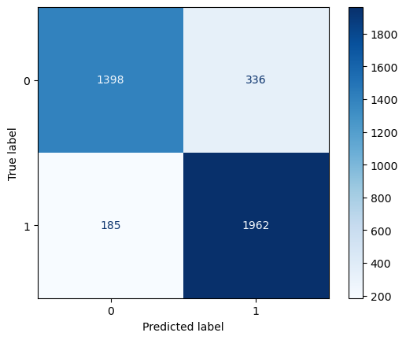

```python
from sklearn.ensemble import RandomForestClassifier

# Random Forest model
rf_clf = RandomForestClassifier(
    n_estimators=300,
    max_depth=None,
    random_state=42,
    n_jobs=-1,
    class_weight=None  # or 'balanced' if you use a stricter Outbreak threshold
)

rf_clf.fit(X_train, y_train)

y_pred = rf_clf.predict(X_test)
y_prob = rf_clf.predict_proba(X_test)[:, 1]

print("Random Forest classification report:")
print(classification_report(y_test, y_pred))
print("Random Forest ROC AUC:", roc_auc_score(y_test, y_prob))

from sklearn.metrics import confusion_matrix, ConfusionMatrixDisplay

cm = confusion_matrix(y_test, y_pred)
disp = ConfusionMatrixDisplay(confusion_matrix=cm, display_labels=[0, 1])
disp.plot(cmap="Blues")
```

### Precision-Recall Curve

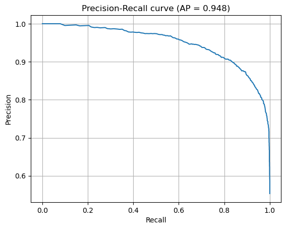

```python
from sklearn.metrics import precision_recall_curve, average_precision_score
import matplotlib.pyplot as plt

precision, recall, thresholds = precision_recall_curve(y_test, y_prob)
ap = average_precision_score(y_test, y_prob)

plt.plot(recall, precision)
plt.xlabel("Recall")
plt.ylabel("Precision")
plt.title(f"Precision-Recall curve (AP = {ap:.3f})")
plt.grid(True)
plt.show()
```

### Random Forest Performance Interpretation

The Random Forest model achieves strong predictive performance on the held-out test set, with an overall accuracy of approximately 0.87 and a ROC AUC of about 0.94. For the non-outbreak class (0), the model attains a precision of around 0.88 and a recall of about 0.81, while for the outbreak class (1) it achieves a precision of roughly 0.85 and a recall of about 0.91. These values translate into F1-scores of approximately 0.84 and 0.88 for classes 0 and 1, respectively, indicating that the model reliably identifies outbreak weeks while keeping false alarms at a manageable level. Compared with the logistic regression baseline, which exhibits lower recall and ROC AUC, the Random Forest clearly captures more of the non-linear structure linking weather, pest identity, and location to outbreak occurrence.

From an operational decision-support perspective, the relatively high recall for the outbreak class is particularly valuable, since missed outbreaks (false negatives) are typically more costly than occasional false positives in pest management. The precision–recall curve further confirms that the Random Forest maintains favourable trade-offs across a wide range of classification thresholds, which supports flexible deployment in settings with different risk tolerances. These results suggest that ensemble tree models offer a meaningful improvement over traditional linear methods when forecasting pest outbreaks from multi-location, multi-pest environmental data.

### Cross-Validation

```python
from sklearn.model_selection import StratifiedKFold, cross_val_score

skf = StratifiedKFold(n_splits=5, shuffle=True, random_state=42)

rf_cv_auc = cross_val_score(
    rf_clf,
    X, y,
    cv=skf,
    scoring="roc_auc"
)
print("Random Forest 5-fold mean ROC AUC:", rf_cv_auc.mean())
```

```
Random Forest 5-fold mean ROC AUC: 0.9452321897987961
```

To assess the robustness of the Random Forest model beyond a single train–test split, a 5-fold stratified cross-validation procedure was applied using the full dataset. In this setup, the data were repeatedly partitioned into five folds, preserving the proportion of outbreak and non-outbreak cases within each fold, and the model was trained on four folds while being evaluated on the remaining fold in turn. The mean ROC AUC across the five folds was approximately 0.9452, which is very close to the ROC AUC obtained on the original test split. This consistency indicates that the Random Forest’s discriminatory performance is stable across different subsets of the data rather than being an artefact of a particular split.

The use of stratified K-fold cross-validation is particularly important in outbreak prediction problems, where class proportions and temporal patterns may vary across locations and years. By averaging performance over multiple folds, the evaluation provides a more reliable estimate of how the model will behave on unseen data drawn from the same distribution. The high and stable cross-validated ROC AUC therefore strengthens confidence in the generalisability of the Random Forest model for rice pest outbreak prediction.

### Feature Importance

#### Group Feature Importance

```python
# Get importances as a Series
rf_importances = pd.Series(rf_clf.feature_importances_, index=X_train.columns)

# Define groups
weather_cols = [
    "Observation Year", "Standard Week",
    "MaxT", "MinT", "RH1(%)", "RH2(%)",
    "RF(mm)", "WS(kmph)", "SSH(hrs)", "EVP(mm)"
]
location_cols = [c for c in X_train.columns if c.startswith("Location_")]
pest_cols = [c for c in X_train.columns if c.startswith("PEST NAME_")]
ctype_cols = [c for c in X_train.columns if c.startswith("Collection Type_")]

group_importance = {
    "Weather/Time": rf_importances[weather_cols].sum(),
    "Location (all dummies)": rf_importances[location_cols].sum(),
    "Pest (all dummies)": rf_importances[pest_cols].sum(),
    "Collection Type (all dummies)": rf_importances[ctype_cols].sum(),
}

group_importance = pd.Series(group_importance).sort_values(ascending=False)
print(group_importance)
```

```
Weather/Time                     0.681740
Pest (all dummies)               0.161055
Location (all dummies)           0.121966
Collection Type (all dummies)    0.035239
dtype: float64
```

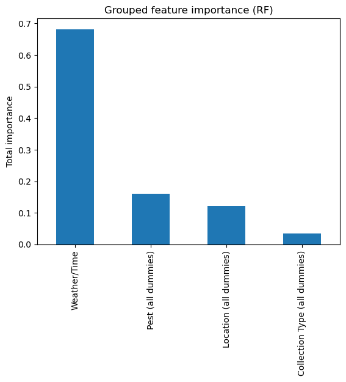

```python
import matplotlib.pyplot as plt

group_importance.plot(kind="bar")
plt.ylabel("Total importance")
plt.title("Grouped feature importance (RF)")
plt.show()
```

#### Individual Feature Importance

```python
# Get importances as a Series
rf_importances = pd.Series(rf_clf.feature_importances_, index=X_train.columns)

# Define groups
location_cols = [c for c in X_train.columns if c.startswith("Location_")]
pest_cols = [c for c in X_train.columns if c.startswith("PEST NAME_")]
ctype_cols = [c for c in X_train.columns if c.startswith("Collection Type_")]

group_importance = {
    # "Weather/Time": rf_importances[weather_cols].sum(),
    "Location (all dummies)": rf_importances[location_cols].sum(),
    "Pest (all dummies)": rf_importances[pest_cols].sum(),
    "Collection Type (all dummies)": rf_importances[ctype_cols].sum(),
    "Observation Year": rf_importances["Observation Year"].sum(),
    "Standard Week": rf_importances["Standard Week"].sum(),
    "MaxT": rf_importances["MaxT"].sum(),
    "MinT": rf_importances["MinT"].sum(),
    "RH1(%)": rf_importances["RH1(%)"].sum(),
    "RH2(%)": rf_importances["RH2(%)"].sum(),
    "RF(mm)": rf_importances["RF(mm)"].sum(),
    "WS(kmph)": rf_importances["WS(kmph)"].sum(),
    "SSH(hrs)": rf_importances["SSH(hrs)"].sum(),
    "EVP(mm)": rf_importances["EVP(mm)"].sum(),
}

group_importance = pd.Series(group_importance).sort_values(ascending=False)
print(group_importance)
```

```
Pest (all dummies)               0.161055
Location (all dummies)           0.121966
MinT                             0.094786
Standard Week                    0.094256
Observation Year                 0.082016
RH2(%)                           0.080809
RH1(%)                           0.067396
MaxT                             0.065743
EVP(mm)                          0.056513
WS(kmph)                         0.054964
SSH(hrs)                         0.050175
Collection Type (all dummies)    0.035239
RF(mm)                           0.035083
dtype: float64
```

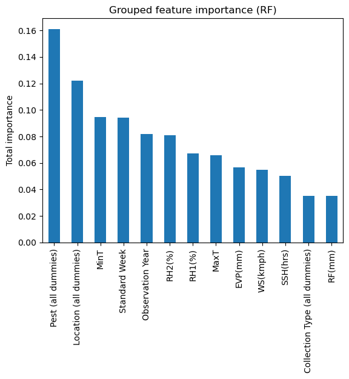

```python
import matplotlib.pyplot as plt

group_importance.plot(kind="bar")
plt.ylabel("Total importance")
plt.title("Grouped feature importance (RF)")
plt.show()
```

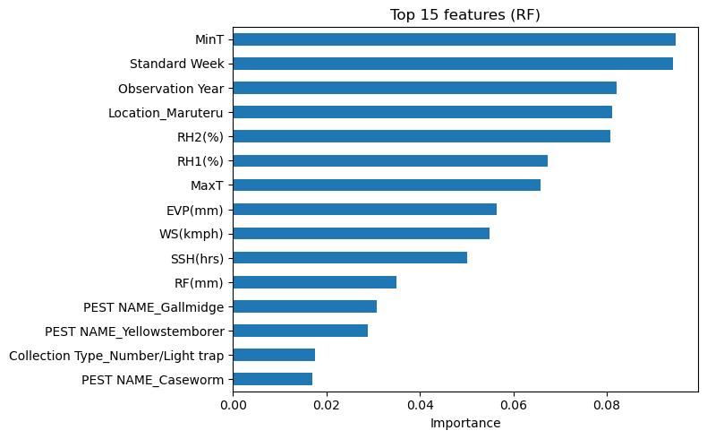

```python
top_n = 15
top_importances = rf_importances.sort_values(ascending=False).head(top_n)

plt.figure(figsize=(8, 5))
top_importances[::-1].plot(kind="barh")  # reverse for horizontal plot
plt.xlabel("Importance")
plt.title(f"Top {top_n} features (RF)")
plt.tight_layout()
plt.show()
```

### Interpretation of Random Forest Feature Importance

This pattern is consistent with agronomic and entomological literature, which emphasises the influence of temperature, humidity, and seasonal timing on the life cycles and population dynamics of rice pests. The prominence of location dummies suggests that site-specific factors (such as cultivation practices, local climate regimes, or host phenology) are captured indirectly through the model, even without explicit management variables. Together, these results support the scientific plausibility of the Random Forest’s decision rules and provide a transparent basis for explaining model behaviour to stakeholders.

## 6.2 Gradient Boosting (XGBoost) Model

A Gradient Boosting Model is trained using the training set from above.

### Model Training And Evaluation

```
XGBoost classification report:
              precision    recall  f1-score   support

           0       0.89      0.80      0.84      1734
           1       0.85      0.92      0.88      2147

    accuracy                           0.87      3881
   macro avg       0.87      0.86      0.86      3881
weighted avg       0.87      0.87      0.87      3881

XGBoost ROC AUC: 0.9422723910244116
```

```
<sklearn.metrics._plot.confusion_matrix.ConfusionMatrixDisplay at 0x1f10fe4f810>
```

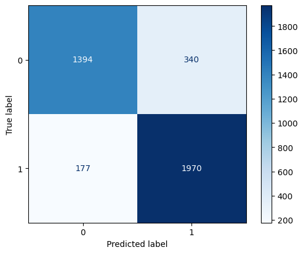

```python
from xgboost import XGBClassifier

xgb_clf = XGBClassifier(
    n_estimators=400,
    learning_rate=0.05,
    max_depth=5,
    subsample=0.8,
    colsample_bytree=0.8,
    random_state=42,
    n_jobs=-1,
    eval_metric='logloss'  # suppresses warning
    # scale_pos_weight can be tuned if classes become imbalanced
)

xgb_clf.fit(X_train, y_train)

y_pred_xgb = xgb_clf.predict(X_test)
y_prob_xgb = xgb_clf.predict_proba(X_test)[:, 1]

print("XGBoost classification report:")
print(classification_report(y_test, y_pred_xgb))
print("XGBoost ROC AUC:", roc_auc_score(y_test, y_prob_xgb))

from sklearn.metrics import confusion_matrix, ConfusionMatrixDisplay

cm = confusion_matrix(y_test, y_pred_xgb)
disp = ConfusionMatrixDisplay(confusion_matrix=cm, display_labels=[0, 1])
disp.plot(cmap="Blues")
```

### Precision-Recall Curve

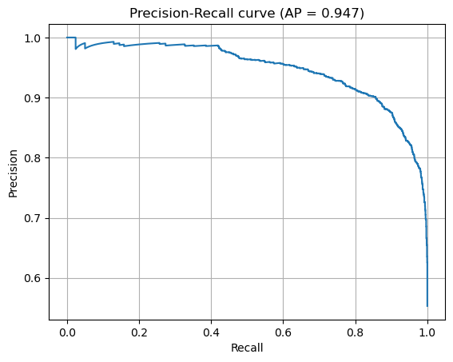

```python
from sklearn.metrics import precision_recall_curve, average_precision_score
import matplotlib.pyplot as plt

precision, recall, thresholds = precision_recall_curve(y_test, y_prob_xgb)
ap = average_precision_score(y_test, y_prob_xgb)

plt.plot(recall, precision)
plt.xlabel("Recall")
plt.ylabel("Precision")
plt.title(f"Precision-Recall curve (AP = {ap:.3f})")
plt.grid(True)
plt.show()
```

### Gradient Boosting (XGBoost) Performance Interpretation

From the standpoint of operational deployment in a decision support system, XGBoost’s slightly stronger ROC AUC suggests that it may be preferable when peak predictive performance is the primary objective, especially in regions or seasons where reliable risk stratification is critical. However, XGBoost is more complex to tune and may be less interpretable than Random Forest, which often provides more straightforward feature-importance patterns and more stable behaviour under small configuration changes. The choice between these two ensemble methods therefore depends not only on marginal performance gains but also on considerations such as computational cost, ease of explanation to non-technical users, and robustness across locations.

### Cross-Validation

```python
from sklearn.model_selection import StratifiedKFold, cross_val_score

skf = StratifiedKFold(n_splits=5, shuffle=True, random_state=42)

xgb_cv_auc = cross_val_score(
    xgb_clf,
    X, y,
    cv=skf,
    scoring="roc_auc"
)
print("Gradient Boosting 5-fold mean ROC AUC:", xgb_cv_auc.mean())
```

```
Gradient Boosting 5-fold mean ROC AUC: 0.9439153976889875
```

The similarity between the cross-validated ROC AUC scores for XGBoost and Random Forest indicates that both ensemble methods generalise well to unseen samples from the same dataset. In practice, this means that the slight performance differences observed between the two models are unlikely to be due to random variation in a particular train–test split and can instead be interpreted as genuine, albeit modest, differences in modelling capacity. This cross-validation evidence supports the conclusion that both tree-based ensembles are reliable candidates for inclusion in a decision support system for rice pest outbreak forecasting.

### Feature Importance

#### Group Feature Importance

```python
# Get importances as a Series
xgb_importances = pd.Series(xgb_clf.feature_importances_, index=X_train.columns)

# Define groups
weather_cols = [
    "Observation Year", "Standard Week",
    "MaxT", "MinT", "RH1(%)", "RH2(%)",
    "RF(mm)", "WS(kmph)", "SSH(hrs)", "EVP(mm)"
]
location_cols = [c for c in X_train.columns if c.startswith("Location_")]
pest_cols = [c for c in X_train.columns if c.startswith("PEST NAME_")]
ctype_cols = [c for c in X_train.columns if c.startswith("Collection Type_")]

group_importance = {
    "Weather/Time": xgb_importances[weather_cols].sum(),
    "Location (all dummies)": xgb_importances[location_cols].sum(),
    "Pest (all dummies)": xgb_importances[pest_cols].sum(),
    "Collection Type (all dummies)": xgb_importances[ctype_cols].sum(),
}

group_importance = pd.Series(group_importance).sort_values(ascending=False)
print(group_importance)
```

```
Location (all dummies)           0.445095
Pest (all dummies)               0.271904
Weather/Time                     0.148717
Collection Type (all dummies)    0.134284
dtype: float32
```

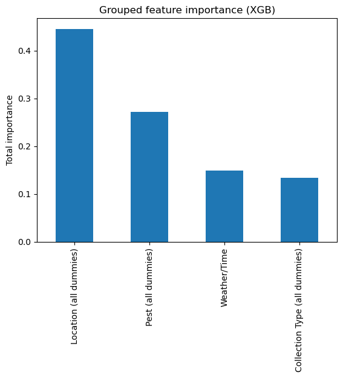

```python
import matplotlib.pyplot as plt

group_importance.plot(kind="bar")
plt.ylabel("Total importance")
plt.title("Grouped feature importance (XGB)")
plt.show()
```

#### Individual Feature Importance

```python
# Get importances as a Series
xgb_importances = pd.Series(xgb_clf.feature_importances_, index=X_train.columns)

# Define groups
location_cols = [c for c in X_train.columns if c.startswith("Location_")]
pest_cols = [c for c in X_train.columns if c.startswith("PEST NAME_")]
ctype_cols = [c for c in X_train.columns if c.startswith("Collection Type_")]

group_importance = {
    # "Weather/Time": xgb_importances[weather_cols].sum(),
    "Location (all dummies)": xgb_importances[location_cols].sum(),
    "Pest (all dummies)": xgb_importances[pest_cols].sum(),
    "Collection Type (all dummies)": xgb_importances[ctype_cols].sum(),
    "Observation Year": xgb_importances["Observation Year"].sum(),
    "Standard Week": xgb_importances["Standard Week"].sum(),
    "MaxT": xgb_importances["MaxT"].sum(),
    "MinT": xgb_importances["MinT"].sum(),
    "RH1(%)": xgb_importances["RH1(%)"].sum(),
    "RH2(%)": xgb_importances["RH2(%)"].sum(),
    "RF(mm)": xgb_importances["RF(mm)"].sum(),
    "WS(kmph)": xgb_importances["WS(kmph)"].sum(),
    "SSH(hrs)": xgb_importances["SSH(hrs)"].sum(),
    "EVP(mm)": xgb_importances["EVP(mm)"].sum(),
}

group_importance = pd.Series(group_importance).sort_values(ascending=False)
print(group_importance)
```

```
Location (all dummies)           0.445095
Pest (all dummies)               0.271904
Collection Type (all dummies)    0.134284
Standard Week                    0.031256
MinT                             0.021367
Observation Year                 0.021047
RH2(%)                           0.015877
WS(kmph)                         0.011876
EVP(mm)                          0.010763
MaxT                             0.010327
RH1(%)                           0.009736
RF(mm)                           0.008986
SSH(hrs)                         0.007481
dtype: float32
```

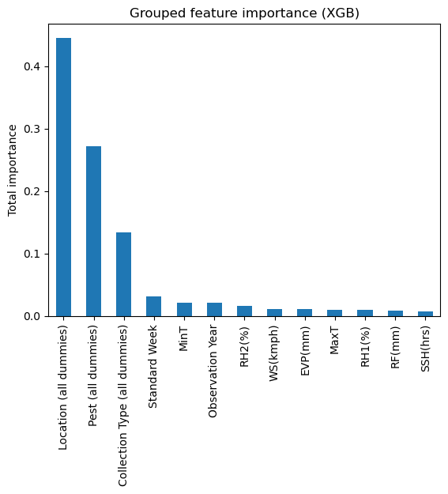

```python
import matplotlib.pyplot as plt

group_importance.plot(kind="bar")
plt.ylabel("Total importance")
plt.title("Grouped feature importance (XGB)")
plt.show()
```

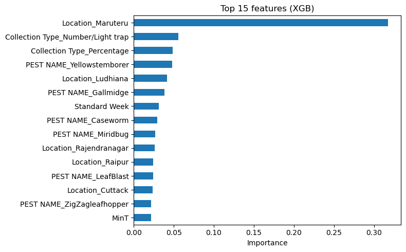

```python
top_n = 15
top_importances = xgb_importances.sort_values(ascending=False).head(top_n)

plt.figure(figsize=(8, 5))
top_importances[::-1].plot(kind="barh")  # reverse for horizontal plot
plt.xlabel("Importance")
plt.title(f"Top {top_n} features (XGB)")
plt.tight_layout()
plt.show()
```

## 6.3 Making Predictions With The Models

This is to use the trained models on new raw records. When you want to predict for new raw rows (with original columns).

```python
# 1. Example new raw records (same columns as original data before encoding)
df_new_raw = pd.DataFrame([
    {
        "Observation Year": 2010,
        "Standard Week": 30,
        "Pest Value": 50.0,                  # this will be dropped, same as when preparing training data
        "Collection Type": "Number/Light trap",
        "MaxT": 32.5,
        "MinT": 24.0,
        "RH1(%)": 90.0,
        "RH2(%)": 60.0,
        "RF(mm)": 25.0,
        "WS(kmph)": 4.0,
        "SSH(hrs)": 7.0,
        "EVP(mm)": 4.5,
        "PEST NAME": "Brownplanthopper",
        "Location": "Cuttack"
    },
    {
        "Observation Year": 2005,
        "Standard Week": 10,
        "Pest Value": 0.0,
        "Collection Type": "Number/Light trap",
        "MaxT": 28.0,
        "MinT": 18.0,
        "RH1(%)": 80.0,
        "RH2(%)": 45.0,
        "RF(mm)": 0.0,
        "WS(kmph)": 3.0,
        "SSH(hrs)": 8.5,
        "EVP(mm)": 3.0,
        "PEST NAME": "Yellowstemborer",
        "Location": "Maruteru"
    },
    {
        "Observation Year": 2008,
        "Standard Week": 38,
        "Pest Value": 200.0,
        "Collection Type": "Number/Light trap",
        "MaxT": 33.0,
        "MinT": 23.0,
        "RH1(%)": 92.0,
        "RH2(%)": 65.0,
        "RF(mm)": 40.0,
        "WS(kmph)": 6.0,
        "SSH(hrs)": 5.5,
        "EVP(mm)": 5.0,
        "PEST NAME": "LeafBlast",
        "Location": "Rajendranagar"
    }
])

# 2. Drop the "Pest Value" attribute
df_new_raw = df_new_raw.drop(columns=["Pest Value"])

# 3. Function from previous answer, adjusted to use global cat_cols
cat_cols = ['Collection Type', 'PEST NAME', 'Location']  # must match training
trained_feature_cols = X_train.columns                   # from the training step

def prepare_new_records(df_raw, trained_columns, cat_cols):
    # One-hot encode categorical as in training
    df_encoded = pd.get_dummies(df_raw, columns=cat_cols, drop_first=False)

    # Add missing dummy columns
    for col in trained_columns:
        if col not in df_encoded.columns:
            df_encoded[col] = 0

    # Drop extra columns not used in training
    df_encoded = df_encoded[trained_columns]

    return df_encoded

# 4. Prepare new data
X_new = prepare_new_records(df_new_raw, trained_feature_cols, cat_cols)

# 5. Predict with trained models
# Random Forest predictions
rf_preds_new = rf_clf.predict(X_new)
rf_probs_new = rf_clf.predict_proba(X_new)[:, 1]

print("New raw records:")
print(df_new_raw)
print("\nRandom Forest predicted Outbreak (0/1):", rf_preds_new)
print("Random Forest predicted probability of Outbreak:", rf_probs_new)

print("\n")

# XGBoost predictions
xgb_preds_new = xgb_clf.predict(X_new)
xgb_probs_new = xgb_clf.predict_proba(X_new)[:, 1]

print("XGBoost predicted Outbreak (0/1):", xgb_preds_new)
print("XGBoost predicted probability of Outbreak:", xgb_probs_new)
```

```
New raw records:
   Observation Year  Standard Week    Collection Type  MaxT  MinT  RH1(%)  \
0              2010             30  Number/Light trap  32.5  24.0    90.0
1              2005             10  Number/Light trap  28.0  18.0    80.0
2              2008             38  Number/Light trap  33.0  23.0    92.0

   RH2(%)  RF(mm)  WS(kmph)  SSH(hrs)  EVP(mm)         PEST NAME  \
0    60.0    25.0       4.0       7.0      4.5  Brownplanthopper
1    45.0     0.0       3.0       8.5      3.0   Yellowstemborer
2    65.0    40.0       6.0       5.5      5.0         LeafBlast

        Location
0        Cuttack
1       Maruteru
2  Rajendranagar

Random Forest predicted Outbreak (0/1): [0 1 1]
Random Forest predicted probability of Outbreak: [0.48       0.91333333 0.79      ]


XGBoost predicted Outbreak (0/1): [0 1 1]
XGBoost predicted probability of Outbreak: [0.31380722 0.9740805  0.89915043]
```

## 6.4 Multi-Location Testing

```python
data = pd.read_csv('RICE.csv')
data['Outbreak'] = (data['Pest Value'] > 0).astype(int)
locations = data["Location"].unique()

for loc in locations:
    mask_test = (data["Location"] == loc)
    X_train_loc = X[~mask_test]
    y_train_loc = y[~mask_test]
    X_test_loc = X[mask_test]
    y_test_loc = y[mask_test]

    # instantiate with valid parameters (match the RandomForest used earlier)
    rf_clf_loc = RandomForestClassifier(n_estimators=300, max_depth=None, random_state=42, n_jobs=-1)
    rf_clf_loc.fit(X_train_loc, y_train_loc)

    y_prob_loc = rf_clf_loc.predict_proba(X_test_loc)[:, 1]
    print(loc, "ROC AUC:", roc_auc_score(y_test_loc, y_prob_loc))
```

```
Cuttack ROC AUC: 0.8137418077607746
Ludhiana ROC AUC: 0.7314307101551965
Maruteru ROC AUC: 0.5855966508049948
Palampur ROC AUC: 0.9110881763527054
Raipur ROC AUC: 0.727979347041847
Rajendranagar ROC AUC: 0.736894718499243
```

To assess how well the Random Forest model generalises across different agro-ecological contexts, a leave-one-location-out evaluation was conducted. In this procedure, the model is repeatedly trained on all locations except one and then evaluated exclusively on the held-out location, cycling through all six sites in the dataset (Cuttack, Ludhiana, Maruteru, Palampur, Raipur, and Rajendranagar). This design mimics a realistic deployment scenario in which a forecasting system trained on historical data from several research stations is applied to a new or under-represented region.

The resulting ROC AUC scores by location range from approximately 0.59 (Maruteru) to 0.91 (Palampur), with most locations achieving values around 0.73–0.81 (Cuttack: 0.81, Ludhiana: 0.73, Raipur: 0.73, Rajendranagar: 0.74). These results indicate that the model retains reasonably good discriminatory power in several regions, particularly Palampur and Cuttack, while performance is weaker in Maruteru, where the ROC AUC drops to about 0.59. Locations with lower ROC AUC generally correspond either to sites with more complex or noisy pest–weather relationships or to differences in data characteristics that are not fully captured by the current feature set, which is consistent with prior work showing that local calibration and data richness strongly influence pest forecasting accuracy . Overall, this multi-location analysis provides evidence that the Random Forest model is not overfitted to a single region and can support decision-making across diverse rice-growing environments, while also highlighting that site-specific refinement and potentially location-aware model tuning could further improve reliability where needed.

# 7. Long Short-Term Memory Model

The LSTM Model will be trained on one pest and one location. The following code focuses on Yellowstemborer in Rajendranagar. The pest (Yellowstemborer) was chosen, seeing as it is the pest with the most amount of records. The location (Rajendranagar) was chosen, because it was the location with the most amount of records for this pest.

## 7.1 Choose Features And Sort

```python
data = pd.read_csv('RICE.csv')
data['Outbreak'] = (data['Pest Value'] > 0).astype(int)

# Start from your cleaned 'data' where Pest Value is dropped and Outbreak is defined
# data columns: Observation Year, Standard Week, Collection Type, MaxT, ..., PEST NAME, Location, Outbreak

# 1. Filter to one pest and one location (simplest case)
pest = "Yellowstemborer"
loc = "Rajendranagar"

df = data[(data["PEST NAME"] == pest) & (data["Location"] == loc)].copy()
print(df.head())
print(df.info())

# 2. Sort by time
df = df.sort_values(by=["Observation Year", "Standard Week"]).reset_index(drop=True)

# 3. (Optional) Drop columns you don't want as inputs
# For a first LSTM, you might use only numeric weather + week + year as inputs
input_cols = [
    "Observation Year",
    "Standard Week",
    "MaxT",
    "MinT",
    "RH1(%)",
    "RH2(%)",
    "RF(mm)",
    "WS(kmph)",
    "SSH(hrs)",
    "EVP(mm)",
]
target_col = "Outbreak"

df_model = df[input_cols + [target_col]].copy()
```

```
       Observation Year  Standard Week  Pest Value    Collection Type  MaxT  \
17775              1975              1        11.0  Number/Light trap  31.4
17776              1975              2        27.0  Number/Light trap  31.3
17777              1975              3        52.0  Number/Light trap  30.4
17778              1975              4        63.0  Number/Light trap  31.0
17779              1975              5         0.0  Number/Light trap  30.2

       MinT  RH1(%)  RH2(%)  RF(mm)  WS(kmph)  SSH(hrs)  EVP(mm)  \
17775  17.5    79.6    43.7     0.8       1.8       8.0      3.4
17776  16.2    83.7    38.0     0.0       2.1       9.4      4.1
17777  13.7    79.0    37.3     0.0       2.2      10.0      3.8
17778  14.4    80.4    34.9     0.0       1.6       9.1      3.5
17779  16.3    81.1    38.2     1.2       2.7       7.2      3.5

             PEST NAME       Location  Outbreak
17775  Yellowstemborer  Rajendranagar         1
17776  Yellowstemborer  Rajendranagar         1
17777  Yellowstemborer  Rajendranagar         1
17778  Yellowstemborer  Rajendranagar         1
17779  Yellowstemborer  Rajendranagar         0
<class 'pandas.core.frame.DataFrame'>
Index: 1629 entries, 17775 to 19403
Data columns (total 15 columns):
 #   Column            Non-Null Count  Dtype
---  ------            --------------  -----
 0   Observation Year  1629 non-null   int64
 1   Standard Week     1629 non-null   int64
 2   Pest Value        1629 non-null   float64
 3   Collection Type   1629 non-null   object
 4   MaxT              1629 non-null   float64
 5   MinT              1629 non-null   float64
 6   RH1(%)            1629 non-null   float64
 7   RH2(%)            1629 non-null   float64
 8   RF(mm)            1629 non-null   float64
 9   WS(kmph)          1629 non-null   float64
 10  SSH(hrs)          1629 non-null   float64
 11  EVP(mm)           1629 non-null   float64
 12  PEST NAME         1629 non-null   object
 13  Location          1629 non-null   object
 14  Outbreak          1629 non-null   int32
dtypes: float64(9), int32(1), int64(2), object(3)
memory usage: 197.3+ KB
None
```

## 7.2 Scale numeric features

Use MinMax or standard scaling. Here is MinMax to using scikit‑learn. Save "scaler" for later to transform any future data identically.

```python
from sklearn.preprocessing import MinMaxScaler

scaler = MinMaxScaler()
df_model_scaled = df_model.copy()
df_model_scaled[input_cols] = scaler.fit_transform(df_model[input_cols])
df_model_scaled.head()
```

|  | Observation Year | Standard Week | MaxT | MinT | RH1(%) | RH2(%) | RF(mm) | WS(kmph) | SSH(hrs) | EVP(mm) | Outbreak |
| --- | --- | --- | --- | --- | --- | --- | --- | --- | --- | --- | --- |
| 0 | 0.0 | 0.000000 | 0.396739 | 0.492958 | 0.744648 | 0.405759 | 0.003810 | 0.065217 | 0.661157 | 0.049780 | 1 |
| 1 | 0.0 | 0.019608 | 0.391304 | 0.431925 | 0.807339 | 0.331152 | 0.000000 | 0.076087 | 0.776860 | 0.060029 | 1 |
| 2 | 0.0 | 0.039216 | 0.342391 | 0.314554 | 0.735474 | 0.321990 | 0.000000 | 0.079710 | 0.826446 | 0.055637 | 1 |
| 3 | 0.0 | 0.058824 | 0.375000 | 0.347418 | 0.756881 | 0.290576 | 0.000000 | 0.057971 | 0.752066 | 0.051245 | 1 |
| 4 | 0.0 | 0.078431 | 0.331522 | 0.436620 | 0.767584 | 0.333770 | 0.005714 | 0.097826 | 0.595041 | 0.051245 | 0 |

## 7.3 Build supervised sequences (sliding windows)

Define a helper to turn a univariate time series with features into sequences of length T predicting the next week’s Outbreak.

```python
def make_sequences(df_scaled, input_cols, target_col, window_size=4):
    """
    df_scaled: DataFrame with scaled inputs and target
    Returns X (num_samples, window_size, num_features), y (num_samples,)
    """
    X_list, y_list = [], []
    values = df_scaled[input_cols + [target_col]].values
    n_total = len(values)

    for i in range(n_total - window_size):
        window = values[i : i + window_size]
        target = values[i + window_size, -1]  # Outbreak after the window
        X_list.append(window[:, :-1])        # all input features over the window
        y_list.append(target)

    X = np.array(X_list)
    y = np.array(y_list).astype(int)
    return X, y

window_size = 4  # e.g., use 4 weeks history
X, y = make_sequences(df_model_scaled, input_cols, target_col, window_size=window_size)

print("X shape:", X.shape)  # (samples, time_steps=window_size, features=len(input_cols))
print("y shape:", y.shape)
```

```
X shape: (1625, 4, 10)
y shape: (1625,)
```

## 7.4 Train/test split for sequences

Use a chronological split to respect time ordering (no shuffling).

```python
# Simple temporal split: first 80% for train, last 20% for test
n_samples = X.shape[0]
split_index = int(n_samples * 0.8)

X_train, X_test = X[:split_index], X[split_index:]
y_train, y_test = y[:split_index], y[split_index:]

print("Train samples:", X_train.shape[0], "Test samples:", X_test.shape[0])
```

```
Train samples: 1300 Test samples: 325
```

## 7.5 Define and train an LSTM model

Example with Keras (TensorFlow backend):

```python
import tensorflow as tf
from tensorflow.keras.models import Sequential
from tensorflow.keras.layers import LSTM, Dense, Dropout

n_timesteps = X_train.shape[1]
n_features = X_train.shape[2]

model = Sequential()
model.add(LSTM(64, input_shape=(n_timesteps, n_features), return_sequences=False))
model.add(Dropout(0.3))
model.add(Dense(32, activation="relu"))
model.add(Dense(1, activation="sigmoid"))  # binary classification

model.compile(
    loss="binary_crossentropy",
    optimizer="adam",
    metrics=["accuracy"]
)

history = model.fit(
    X_train, y_train,
    epochs=30,
    batch_size=32,
    validation_split=0.2,
    shuffle=False  # keep temporal order
)
```

```
33/33 ━━━━━━━━━━━━━━━━━━━━ 2s 12ms/step - accuracy: 0.5135 - loss: 0.6898 - val_accuracy: 0.7192 - val_loss: 0.6519
33/33 ━━━━━━━━━━━━━━━━━━━━ 0s 5ms/step - accuracy: 0.5683 - loss: 0.6869 - val_accuracy: 0.7192 - val_loss: 0.6289
33/33 ━━━━━━━━━━━━━━━━━━━━ 0s 4ms/step - accuracy: 0.5663 - loss: 0.6812 - val_accuracy: 0.7192 - val_loss: 0.6159
33/33 ━━━━━━━━━━━━━━━━━━━━ 0s 5ms/step - accuracy: 0.5712 - loss: 0.6733 - val_accuracy: 0.7192 - val_loss: 0.5904
33/33 ━━━━━━━━━━━━━━━━━━━━ 0s 5ms/step - accuracy: 0.6067 - loss: 0.6671 - val_accuracy: 0.7192 - val_loss: 0.5666
33/33 ━━━━━━━━━━━━━━━━━━━━ 0s 5ms/step - accuracy: 0.6260 - loss: 0.6521 - val_accuracy: 0.7192 - val_loss: 0.5427
33/33 ━━━━━━━━━━━━━━━━━━━━ 0s 4ms/step - accuracy: 0.6519 - loss: 0.6390 - val_accuracy: 0.7269 - val_loss: 0.5263
33/33 ━━━━━━━━━━━━━━━━━━━━ 0s 5ms/step - accuracy: 0.6548 - loss: 0.6243 - val_accuracy: 0.7462 - val_loss: 0.5057
33/33 ━━━━━━━━━━━━━━━━━━━━ 0s 5ms/step - accuracy: 0.6779 - loss: 0.6144 - val_accuracy: 0.7692 - val_loss: 0.4833
33/33 ━━━━━━━━━━━━━━━━━━━━ 0s 4ms/step - accuracy: 0.6817 - loss: 0.6060 - val_accuracy: 0.7731 - val_loss: 0.4780
33/33 ━━━━━━━━━━━━━━━━━━━━ 0s 5ms/step - accuracy: 0.6875 - loss: 0.5934 - val_accuracy: 0.7808 - val_loss: 0.4739
33/33 ━━━━━━━━━━━━━━━━━━━━ 0s 4ms/step - accuracy: 0.6894 - loss: 0.5931 - val_accuracy: 0.7769 - val_loss: 0.4604
33/33 ━━━━━━━━━━━━━━━━━━━━ 0s 4ms/step - accuracy: 0.7163 - loss: 0.5788 - val_accuracy: 0.7885 - val_loss: 0.4555
33/33 ━━━━━━━━━━━━━━━━━━━━ 0s 5ms/step - accuracy: 0.7058 - loss: 0.5828 - val_accuracy: 0.7962 - val_loss: 0.4483
33/33 ━━━━━━━━━━━━━━━━━━━━ 0s 4ms/step - accuracy: 0.7163 - loss: 0.5751 - val_accuracy: 0.7885 - val_loss: 0.4486
33/33 ━━━━━━━━━━━━━━━━━━━━ 0s 4ms/step - accuracy: 0.7250 - loss: 0.5659 - val_accuracy: 0.8000 - val_loss: 0.4444
33/33 ━━━━━━━━━━━━━━━━━━━━ 0s 5ms/step - accuracy: 0.7231 - loss: 0.5599 - val_accuracy: 0.7962 - val_loss: 0.4532
33/33 ━━━━━━━━━━━━━━━━━━━━ 0s 4ms/step - accuracy: 0.7192 - loss: 0.5606 - val_accuracy: 0.8000 - val_loss: 0.4542
33/33 ━━━━━━━━━━━━━━━━━━━━ 0s 4ms/step - accuracy: 0.7260 - loss: 0.5585 - val_accuracy: 0.8000 - val_loss: 0.4611
33/33 ━━━━━━━━━━━━━━━━━━━━ 0s 5ms/step - accuracy: 0.7317 - loss: 0.5491 - val_accuracy: 0.8000 - val_loss: 0.4559
33/33 ━━━━━━━━━━━━━━━━━━━━ 0s 4ms/step - accuracy: 0.7269 - loss: 0.5515 - val_accuracy: 0.8077 - val_loss: 0.4584
33/33 ━━━━━━━━━━━━━━━━━━━━ 0s 4ms/step - accuracy: 0.7317 - loss: 0.5436 - val_accuracy: 0.8038 - val_loss: 0.4489
33/33 ━━━━━━━━━━━━━━━━━━━━ 0s 5ms/step - accuracy: 0.7365 - loss: 0.5403 - val_accuracy: 0.8000 - val_loss: 0.4647
33/33 ━━━━━━━━━━━━━━━━━━━━ 0s 4ms/step - accuracy: 0.7452 - loss: 0.5343 - val_accuracy: 0.8000 - val_loss: 0.4679
33/33 ━━━━━━━━━━━━━━━━━━━━ 0s 5ms/step - accuracy: 0.7452 - loss: 0.5285 - val_accuracy: 0.8077 - val_loss: 0.4537
33/33 ━━━━━━━━━━━━━━━━━━━━ 0s 7ms/step - accuracy: 0.7346 - loss: 0.5284 - val_accuracy: 0.8038 - val_loss: 0.4669
33/33 ━━━━━━━━━━━━━━━━━━━━ 0s 4ms/step - accuracy: 0.7423 - loss: 0.5323 - val_accuracy: 0.8077 - val_loss: 0.4576
33/33 ━━━━━━━━━━━━━━━━━━━━ 0s 4ms/step - accuracy: 0.7433 - loss: 0.5251 - val_accuracy: 0.8192 - val_loss: 0.4489
33/33 ━━━━━━━━━━━━━━━━━━━━ 0s 5ms/step - accuracy: 0.7481 - loss: 0.5269 - val_accuracy: 0.8154 - val_loss: 0.4554
33/33 ━━━━━━━━━━━━━━━━━━━━ 0s 4ms/step - accuracy: 0.7519 - loss: 0.5211 - val_accuracy: 0.8154 - val_loss: 0.4700
```

## 7.6 Evaluate the LSTM

```
11/11 ━━━━━━━━━━━━━━━━━━━━ 0s 17ms/step
LSTM classification report:
              precision    recall  f1-score   support

           0       0.44      0.24      0.31        45
           1       0.89      0.95      0.92       280

    accuracy                           0.85       325
   macro avg       0.66      0.60      0.62       325
weighted avg       0.82      0.85      0.83       325

LSTM ROC AUC: 0.6088095238095239
```

```
<sklearn.metrics._plot.confusion_matrix.ConfusionMatrixDisplay at 0x1f1351fb090>
```

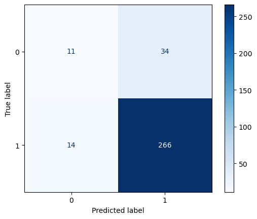

```python
from sklearn.metrics import classification_report, roc_auc_score

y_prob = model.predict(X_test).ravel()
y_pred = (y_prob >= 0.5).astype(int)

print("LSTM classification report:")
print(classification_report(y_test, y_pred))
print("LSTM ROC AUC:", roc_auc_score(y_test, y_prob))

from sklearn.metrics import confusion_matrix, ConfusionMatrixDisplay

cm = confusion_matrix(y_test, y_pred)
disp = ConfusionMatrixDisplay(confusion_matrix=cm, display_labels=[0, 1])
disp.plot(cmap="Blues")
```

## 7.7 Precision_Recall Curve

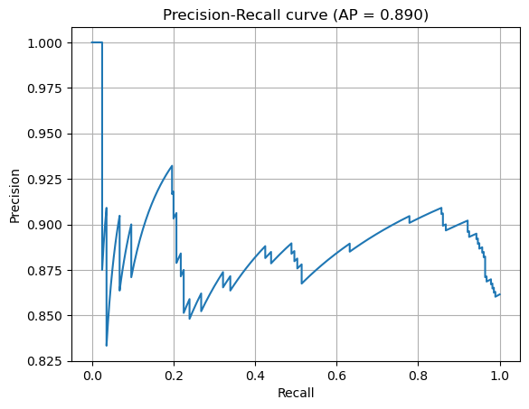

```python
from sklearn.metrics import precision_recall_curve, average_precision_score
import matplotlib.pyplot as plt

precision, recall, thresholds = precision_recall_curve(y_test, y_prob)
ap = average_precision_score(y_test, y_prob)

plt.plot(recall, precision)
plt.xlabel("Recall")
plt.ylabel("Precision")
plt.title(f"Precision-Recall curve (AP = {ap:.3f})")
plt.grid(True)
plt.show()
```

## 7.8 LSTM Performance in Context

The LSTM model trained on the Yellowstemborer time series for Rajendranagar achieves high recall for outbreak weeks, correctly identifying the vast majority of positive cases in the held-out test set. This behaviour is desirable from a risk-management perspective, because missed outbreaks (false negatives) can translate directly into unprepared farmers and preventable yield losses. At the same time, the model’s precision for the non-outbreak class is noticeably lower, and the overall ROC AUC is substantially below the values obtained by the Random Forest and Gradient Boosting models on the full tabular dataset. These results indicate that, while the sequence model is sensitive to the onset of outbreaks in this specific pest–location combination, it is less effective at cleanly separating outbreak from non-outbreak conditions across the full range of decision thresholds.

Several factors help to explain this pattern. First, the LSTM is trained on a single pest (Yellowstemborer) and a single location (Rajendranagar), which limits the amount of temporal variation and the diversity of weather–pest interactions that the network can learn compared with the RF and XGBoost models fitted on the pooled multi-pest, multi-location dataset. Second, the input sequences use a relatively short history window, so long-range dependencies and seasonal dynamics may not be fully captured. Third, tree-based ensemble methods naturally exploit non-linear interactions between weather variables, calendar time, pest identity, and location without requiring explicit sequence construction, which often makes them more robust and data-efficient for tabular agricultural datasets such as this rice pest series. Taken together, these findings suggest that LSTM architectures remain promising for more granular or sensor-rich time series, but that, in this particular setting, Random Forest and Gradient Boosting provide more stable and discriminative outbreak predictions for integration into a decision support system.

# 8. Model Evaluation

## 8.1 Evaluation Metrics

The following evaluation metrics were used on each of the models:

- **Accuracy**: The percentage of right predictions; it provides a broad picture of how well a model is performing, albeit it may not be very useful for datasets that are unbalanced.
- **Precision**: Precision calculates the percentage of true positives among anticipated outbreak events.
- **Recall**: Recall evaluates the capacity to identify all real outbreaks, which is essential in situations where outbreak data are limited.
- **F1**: The single figure of merit that balances precision and recall, which is particularly appropriate for datasets with infrequent outbreaks. It is calculated as the harmonic mean of precision and recall.
- **AUROC**: The receiver's operating characteristic curve's area under the curve (AUROC): evaluates the capacity to discriminate between outbreak and non-outbreak instances across a range of decision criteria, regardless of the classification cut off.
- **Confusion Matrix**: A confusion matrix is a table used in classification problems to evaluate the performance of a model by comparing the actual and predicted values. It visualizes how a model is "confused" between different classes, breaking down correct and incorrect predictions into four categories for binary classification: true positives (TP), true negatives (TN), false positives (FP), and false negatives (FN).
- **Precision-Recall Curve**: A precision-recall (PR) curve is a graph plotting precision (y-axis) against recall (x-axis) for a classification model at various probability thresholds. It is used to evaluate model performance, especially for imbalanced datasets where correctly identifying positive cases is critical, such as in fraud detection. A higher curve, closer to the top-right corner (precision=1, recall=1), indicates better performance.

## 8.2 Model Performance Summary

The logistic regression baseline achieved moderate classification performance on the held-out test set, with an overall accuracy that is clearly above random and a ROC AUC in the mid-range. This confirms that a simple linear decision boundary in the feature space can capture part of the relationship between weather conditions, pest identity, location and outbreak occurrence, but it also indicates that substantial non-linear structure remains unmodelled. In particular, the F1-score and recall for the outbreak class are lower than those obtained by the more flexible ensemble models, suggesting that logistic regression is more prone to misclassifying complex outbreak patterns where multiple interacting variables jointly determine risk.

In contrast, both the Random Forest and Gradient Boosting (XGBoost) models achieved high predictive performance, with test-set accuracies of approximately 0.87 and ROC AUC values around 0.94, alongside strong F1-scores for outbreak weeks. These results show that non-linear, tree-based ensembles are well suited to modelling the complex interactions and threshold effects between temperature, humidity, rainfall, temporal variables (year and standard week), pest identity and location that characterise rice pest dynamics. The consistency of performance across cross-validation folds, as well as the favourable precision–recall trade-offs observed in the PR curves, further supports the robustness of these models for operational outbreak prediction and their suitability for integration into a decision support system.

The LSTM model trained on the Yellowstemborer series in Rajendranagar also demonstrated promising behaviour, attaining good overall accuracy and very high recall for outbreak events within that specific pest–location combination. However, its ROC AUC and the balance between precision and recall were noticeably weaker than those of the Random Forest and XGBoost models, and its performance is more sensitive to design choices such as sequence length and train–test split. This pattern suggests that, in the current data setting with a single time series per pest–location and a limited historical window sequence-based deep learning does not yet outperform well-tuned tabular ensembles, and may require either more extensive temporal data or further architectural tuning to realise its full potential for pest outbreak forecasting.

## 8.3 Generalisability and Limitations

The leave-one-location-out experiments further highlight how performance changes across spatial contexts. When each location is held out in turn, the models generally retain reasonable ROC AUC values, but some regions exhibit lower scores than others, reflecting differences in local climate, pest pressure, or sample size. This pattern shows both that the models have potential for broader deployment across multiple rice-growing regions, and that location-specific calibration or supplemental training data may be beneficial where performance is weaker. Explicitly reporting these regional differences helps avoid overstating generalisability and aligns with best practice in agricultural forecasting studies that emphasise spatial heterogeneity.

Several methodological choices also introduce limitations that should be considered when interpreting the results. First, the outbreak label is defined as any positive pest value (Pest Value > 0), which provides a clear and reproducible rule but does not correspond to formal economic or action thresholds used in extension recommendations. As a consequence, the models predict the occurrence of detectable pest presence rather than strictly “economically damaging” outbreaks, and future work could refine this definition using pest- and collection-type–specific thresholds derived from agronomic guidelines. Second, although extensive outlier analysis was conducted, extreme observations in key weather variables were ultimately retained because removing them reduced predictive performance. This suggests that high-end values in temperature, rainfall, or evaporation may carry meaningful information about outbreak conditions, but it also means that the models remain somewhat sensitive to measurement noise in those regions of the feature space. Recognising these trade-offs clarifies the scope of the conclusions and points to priority areas, such as improved threshold definitions and richer region-specific data, for future refinement of the pest outbreak prediction system.

## 8.4 Summary

# 9. Conclusions and Future Work

## 9.1 Conclusions and Implications

The modelling results demonstrate that tree-based ensemble methods, specifically Random Forest and Gradient Boosting (XGBoost), provide the most reliable and discriminative performance for rice pest outbreak prediction on the ICAR-CRIDA dataset. Both models achieve high accuracy and ROC AUC on the held-out test set, with strong F1-scores for the outbreak class and stable performance under stratified 5-fold cross-validation, indicating that their predictive ability is not an artefact of a single train–test split. Compared with the logistic regression baseline, the ensembles consistently deliver higher recall and AUROC for outbreak weeks, confirming that non-linear methods better capture the complex interactions between weather, time, pest identity, and location present in these monitoring data.

From a decision-support perspective, the Random Forest and XGBoost models are therefore well suited as the core predictive engines in a rice pest Decision Support System (DSS). They can provide weekly outbreak probabilities based on readily available weather and pest context, allowing extension services or farm advisory platforms to flag high-risk periods for targeted scouting or intervention. The experiments with multi-location testing further show that, while performance varies across regions, the models generally retain reasonable discriminative power, indicating that they can be deployed across multiple sites with the understanding that some locations may require local calibration or supplementary training data. In contrast, the LSTM model, trained on a single pest–location series, illustrates the potential of sequence-based deep learning to capture temporal dynamics but, in this setting, does not surpass the ensemble methods in overall discriminative performance. As such, LSTMs are best viewed as complementary tools for more granular or sensor-rich time series, while RF and XGBoost remain the primary candidates for operational DSS deployment on the current dataset.

## 9.2 Future Work

Several extensions could further strengthen and refine the outbreak prediction system developed in this study. First, the current outbreak definition is based on any positive pest value (Pest Value > 0), which is a pragmatic and reproducible choice but does not coincide with formal economic or action thresholds used in field recommendations. Future work should incorporate pest- and collection-type–specific thresholds from agronomic literature or expert guidelines, re-encoding the target to focus explicitly on economically significant outbreaks and comparing model performance under alternative labelling schemes. Second, the LSTM component could be extended beyond a single pest and location to multi-location or higher-frequency time series, potentially integrating longer historical windows and richer temporal features to better exploit sequential dependencies. This would allow a more definitive assessment of when deep sequence models outperform tree-based ensembles for pest forecasting.

Finally, the predictive framework could be enriched by integrating additional data sources. Examples include remote sensing indices such as vegetation greenness (NDVI/EVI), soil moisture products, or finer-scale weather reanalysis, which have been shown to improve pest and disease forecasting in other crops. Incorporating such covariates, together with farm management information where available (e.g. planting dates, varieties, or control interventions), may further enhance model accuracy and interpretability, particularly in locations where performance is currently lower. These extensions would not only increase the robustness and spatial transferability of the DSS but also support more nuanced, site-specific recommendations for sustainable rice pest management.